# Regression Models Project

David Pérez Sánchez

Thursday, December 18, 2014

## Sypnosis

We want to predict from `mtcars` data set which is better an automatic car or a manual transmission car per mpg and quantify this difference.

## Getting Started

Let’s going to load the package `datasets` and choose the mtcars data set.

```r
library(datasets)
data(mtcars)
```

We’re going to load the graphics package `ggplot2` and `gridExtra` packages.

```r
library(ggplot2)
library(gridExtra)
```

## Exploratory Analysis

We summarize the data:

```r
summary(mtcars)
```

```
##       mpg             cyl             disp             hp
##  Min.   :10.40   Min.   :4.000   Min.   : 71.1   Min.   : 52.0
##  1st Qu.:15.43   1st Qu.:4.000   1st Qu.:120.8   1st Qu.: 96.5
##  Median :19.20   Median :6.000   Median :196.3   Median :123.0
##  Mean   :20.09   Mean   :6.188   Mean   :230.7   Mean   :146.7
##  3rd Qu.:22.80   3rd Qu.:8.000   3rd Qu.:326.0   3rd Qu.:180.0
##  Max.   :33.90   Max.   :8.000   Max.   :472.0   Max.   :335.0
##       drat             wt             qsec             vs
##  Min.   :2.760   Min.   :1.513   Min.   :14.50   Min.   :0.0000
##  1st Qu.:3.080   1st Qu.:2.581   1st Qu.:16.89   1st Qu.:0.0000
##  Median :3.695   Median :3.325   Median :17.71   Median :0.0000
##  Mean   :3.597   Mean   :3.217   Mean   :17.85   Mean   :0.4375
##  3rd Qu.:3.920   3rd Qu.:3.610   3rd Qu.:18.90   3rd Qu.:1.0000
##  Max.   :4.930   Max.   :5.424   Max.   :22.90   Max.   :1.0000
##        am              gear            carb
##  Min.   :0.0000   Min.   :3.000   Min.   :1.000
##  1st Qu.:0.0000   1st Qu.:3.000   1st Qu.:2.000
##  Median :0.0000   Median :4.000   Median :2.000
##  Mean   :0.4062   Mean   :3.688   Mean   :2.812
##  3rd Qu.:1.0000   3rd Qu.:4.000   3rd Qu.:4.000
##  Max.   :1.0000   Max.   :5.000   Max.   :8.000
```

We have interested in the continous variables and am variable. We’re going to plot mpg variable in function of those varibles.

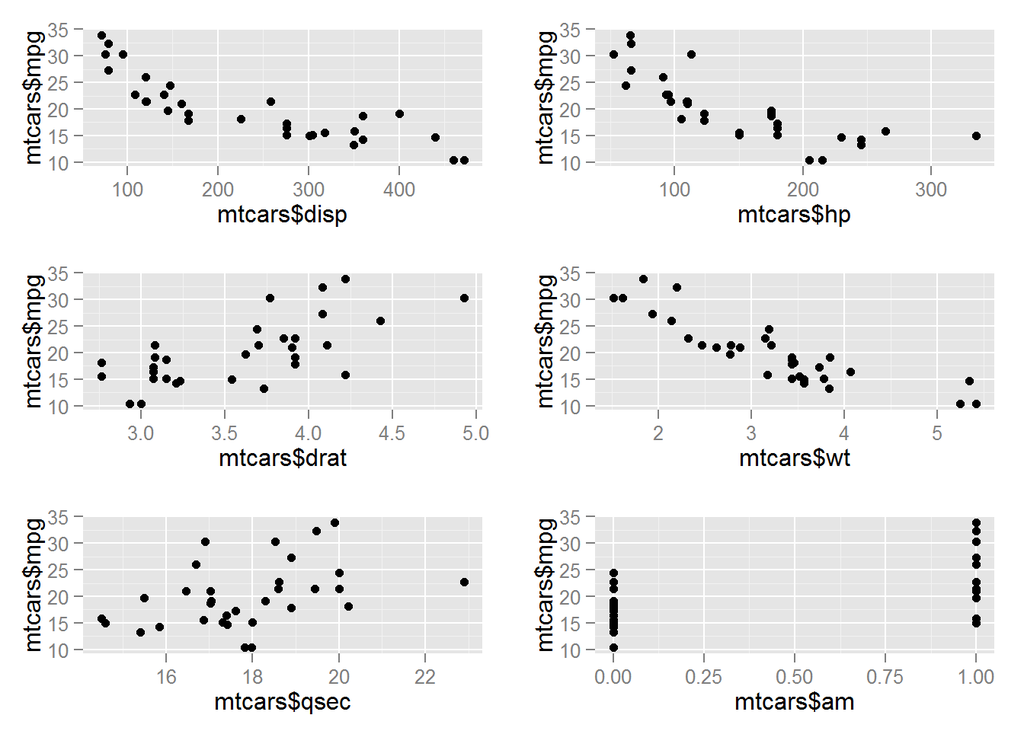

We observe that the more linear tendece is with the wt variable. We choose this variable to make the regression model.

## Regression Models

Let’s then make a regression model with the variables am and wt

```r
fit <- lm(mpg ~ factor(am) + wt, data=mtcars)
```

We look at the coefficients of the model

```
##                Estimate Std. Error     t value     Pr(>|t|)
## (Intercept) 37.32155131  3.0546385 12.21799285 5.843477e-13
## factor(am)1 -0.02361522  1.5456453 -0.01527855 9.879146e-01
## wt          -5.35281145  0.7882438 -6.79080719 1.867415e-07
```

We observe that there is not a significant difference between automatic and manuals cars. Let’ quantify it. We calculate the difference between automatic and manuals transmission cars by average weigth car.

```r
automatic <- summary(fit)$coef[1] + summary(fit)$coef[3]*mean(mtcars$wt)
manual <- summary(fit)$coef[1] + summary(fit)$coef[2]+ summary(fit)$coef[3]*mean(mtcars$wt)
difference <- c("manual"=manual, "automatic"= automatic)
difference
```

```
##    manual automatic
##  20.07660  20.10022
```

We look at a R square: $R^2$ = 0.7528348. But it is the opposite that we think. We plot it to see if the model is correct:

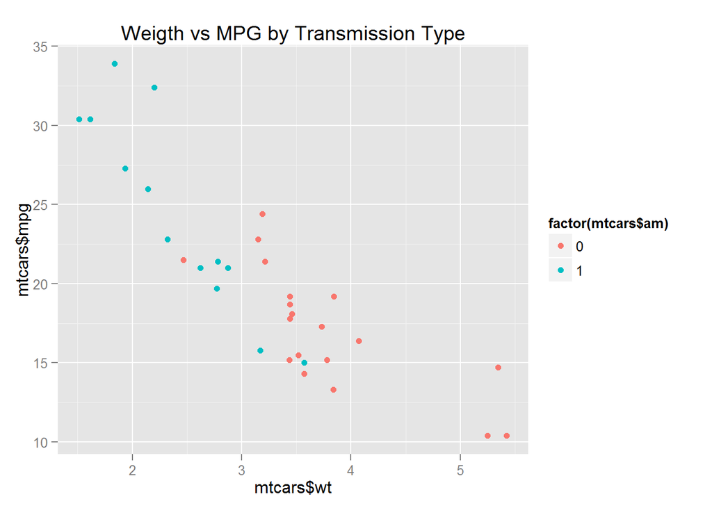

Let’s do it:

```r
fit2 <- lm(mpg ~ factor(am) + wt + factor(am)*wt, data=mtcars)
```

We look at to the coefficients:

```
##                 Estimate Std. Error   t value     Pr(>|t|)
## (Intercept)    31.416055  3.0201093 10.402291 4.001043e-11
## factor(am)1    14.878423  4.2640422  3.489277 1.621034e-03
## wt             -3.785908  0.7856478 -4.818836 4.551182e-05
## factor(am)1:wt -5.298360  1.4446993 -3.667449 1.017148e-03
```

The model tells us that the manual transmission cars are better than the transmissions one for a 1000 lb of diference of weigth. Nevertheless, for an average weigth car is better the automatic transmission And we make a quantification:

```r
a1 <- summary(fit2)$coef[1]+summary(fit2)$coef[3]*1
m1 <- (summary(fit2)$coef[1]+ summary(fit2)$coef[2]
        + summary(fit2)$coef[3]*1+summary(fit2)$coef[4]*1)
wt1000 <- c("manual"=m1, "automatic"=a1)
a2 <- summary(fit2)$coef[1]+summary(fit2)$coef[3]*mean(mtcars$wt)
m2 <- (summary(fit2)$coef[1]+ summary(fit2)$coef[2]
        + summary(fit2)$coef[3]*mean(mtcars$wt)+summary(fit2)$coef[4]*mean(mtcars$wt))
wtMean <- c("manual"=m2, "automatic"=a2)
difference <- rbind(wt1000, wtMean)
difference
```

```
##          manual automatic
## wt1000 37.21021  27.63015
## wtMean 17.06812  19.23584
```

And the R square is: $R^2$ = 0.8330375

## Residuals Plot and Diagnostic

We plot the residuals plot to see how we can improve our model.

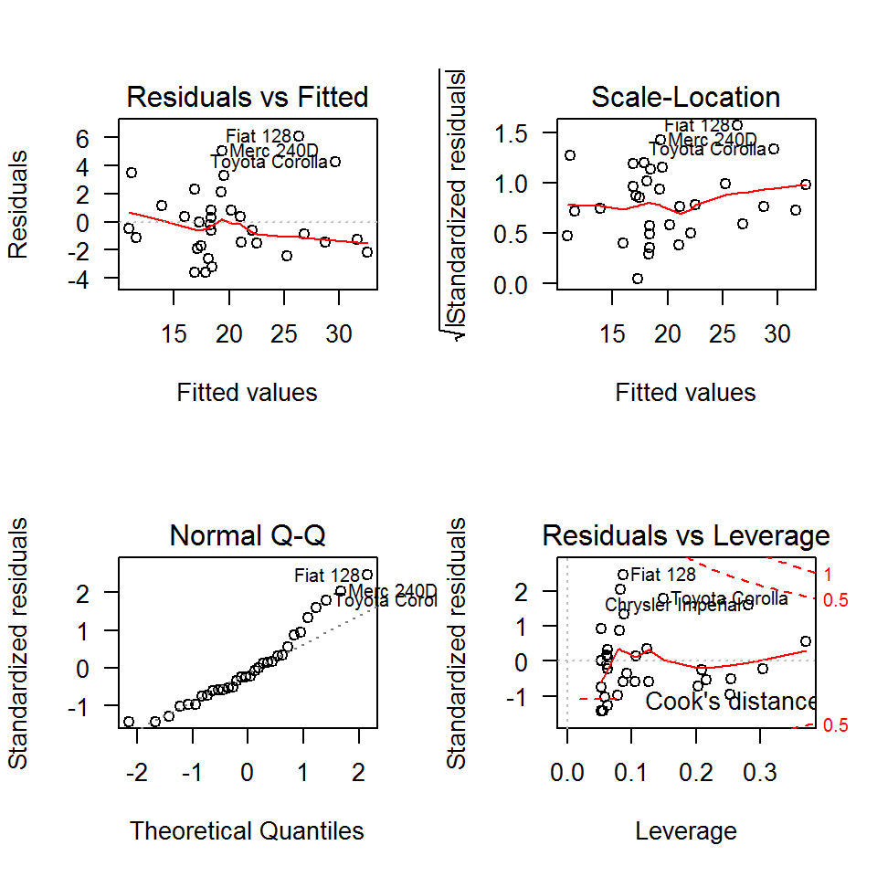

```
##          Duster 360          Camaro Z28         AMC Javelin
##        -3.600365503        -3.578170470        -3.211463020
##    Dodge Challenger          Datsun 710        Lotus Europa
##        -2.589660880        -2.418976083        -2.149980379
##         Merc 450SLC      Ford Pantera L           Mazda RX4
##        -1.905324922        -1.697348262        -1.493695675
##        Ferrari Dino           Fiat X1-9         Honda Civic
##        -1.431055471        -1.416419272        -1.223385040
##  Cadillac Fleetwood       Porsche 914-2           Merc 280C
##        -1.140040848        -0.854144327        -0.592533483
##       Toyota Corona Lincoln Continental             Valiant
##        -0.583793327        -0.481292938        -0.216815332
##          Merc 450SL   Hornet Sportabout          Volvo 142E
##         0.005379702         0.307466517         0.359787209
##          Merc 450SE            Merc 280       Mazda RX4 Wag
##         0.392588263         0.807466517         0.822792671
##       Maserati Bora      Hornet 4 Drive    Pontiac Firebird
##         1.136358948         2.155637322         2.340759068
##            Merc 230   Chrysler Imperial      Toyota Corolla
##         3.309553333         3.519620367         4.275153925
##           Merc 240D            Fiat 128
##         5.060989634         6.090911754
```